# mcdevitt_nlp_homework_07_clustering

### imdb film reviews - clustering the reviews

| I don't like to write like God. It is only because you never do it, though, that the critics think you can't do it. |
| --- |
| -- Ernest Hemingway |

#### MSDS 7337 - Natural Language Processing - Homework 07

##### 19-nov-2018

### Assignment description

Cluster the reviews that you collected in homework 5, by doing the following:

1. In Python, select any one of the clustering methods covered in this course. Run it over the collection of reviews, and show at least two different ways of clustering the reviews, e.g., changing k in k-Means clustering or changing where you “cut” in Agnes or Diana.
2. Try to write a short phrase to characterize (give a natural interpretation of) what each cluster is generally centered on semantically. Is this hard to do in some cases? If so, make note of that fact.
3. Explain which of the two clustering results from question 1 is preferable (if one of them is), and why. Submit all of your inputs and outputs and your code for this assignment, along with a brief written explanation of your findings.

### Data preparation, feature construction

- 100 movie reviews were downloaded from the IMDB web-site
- the reviews (approx 25 reviews each) are associated to four different films :
  - Stranger Than Paradise, Fargo, The Big Lebowski, and Small Apartments
    - these four films were chosen from the base category drama
    - each of these films has a certain cult following for its unique quirkiness
    - two of these films (Lebowski and Fargo) are Coen Brothers films
- the text from each review was normalized in the following method :
  - contractions expanded
  - part of speech tagged
  - lemmatized, using the part of speech tags in WordNet
  - special characters removed
  - stop words removed, using NLTK english stop words
    - a small list of additional stop words were added to base list, to remove terms that are common in film reviews, e.g., film, movie, cinema, scene, and similar common terms
  - for one sequence of clusters developed here, an additional part of speech tagging was completed, and only Noun and Verb forms of tokens were retained - this was done to evaluate if using limited parts of speech in the clustered corpus produces more distinct cluster key features
  - features were developed using TF-IDF feature matrix
  - the feature matrix was used for non-supervised learning using k-means clustering method

### Clustering evaluation

#### Use 2 methods to normalize the corpus

- normalize_corpus() - returns all text values in corpus, regardless of part of speech
- normalize_corpus_NV() - returns only parts of speech which are Noun or Verb forms

#### k-means clustering

- evaluate number of clusters from 2 to 6

#### results summary table includes :

- in each cluster
  - number of reviews
  - mean and median value of the ratings for those reviews
  - number of occurrences of each film (four films considered in this sample)
  - list of key features, in decreasing order of importance

#### plot of each cluster space

- using multidimensional scaling (MDS) to visualize cosine distance between each review feature matrix
- each review feature is tagged with its associated film title in the feature space

The methods used in this evaluation are based on the methods outlined in "Text Analytics with Python", Sarker, Chapter 6

### Results

The specific results for each of the 10 cluster analyses are shown at the end of this document. The results are displayed both as a tabular summary and a plot. The tabular summary shows the number of reviews included in each cluster, the mean and median values of the ratings assigned, the distribution of the films within each cluster, along with the list of key features identified. The plot shows a 2-D view of the features as developed within the MDS cosine-distance domain, with a color code to designate the cluster assignment, a label of the associated film, and a legend displaying several of the key features defining that cluster.

For brevity, I will compare the results from the two 4-cluster models, for which the distinction between the two is the corpus used to develop the clusters, in the first case, all of the tokens after normalization, in the second case, the corpus is subsetted to only include noun and verb forms.

We can make the following observations :

##### Regarding metric characterizations

In Tables 1 and 2 below are the summary characteristics for each of the k = 4 clusters.

The columns labeled 'STP', 'FAR', 'SAP', 'TBL' are abbreviations for each of the films in the evaluation, where STP = Stranger Than Paradise; FAR = Fargo; SAP = Small Apartment; and TBL = The Big Lebowski. The values in the columns indicate the number of occurrences of each film are associated that cluster.

- in both clusters sets :
  - there is a cluster strongly associated to the film TBL
  - there is a cluster strongly associated to the film FAR
- some differentiation between cluster sets :
  - there is a cluster strongly associated to the film SAP only in the first cluster set
  - there are 2 clusters in the 2nd set that are even contribution of SAP and STP (clusters 0 and 2)
    - they are distinguished by higher and lower ratings for the reviews, i.e., 2 groups of reviewers - one who generally appreciated these 2 films, and another group who generally did not appreciate these films

So, for the general characterization by this method, the differentiation between *All POS corpus* and *Only Noun & Verb Corpus* was the ability to distinguish reviewers who did or did not appreciate the 2 films STP and SAP.

##### Regarding key features for each set of clusters

In Table 3 below are the key lexical features for both of the k = 4 clusters.

- some cluster characterizations that we can make :
  - there is a **The Big Lebowski** cluster - for all of the key features ... it's about **the Dude** :
    - dude, bridge, brother, lebowski, john, bowling, goodman, jeff, character, humor
    - since the key features are primarily nouns, this is not modified in the comparison between ALL POS and Noun & Verb Only POS corpora
  - there is **Fargo** based cluster with these key features :
    - fargo, episode, series, tv, like, really, first, bad, great, time
    - fargo, episode, series, tv, something, time, character, cast, end, people
    - a characteristic that distinguishes the Fargo cluster are the key references to TV series. Since this is the only film of the set that also had (apparently) a TV series of the same name, this cluster may be characterized as the **'Film with TV Series'** cluster
  - there is **Dark & Strange** cluster, primarily associated with the film Stranger Than Paradise, that includes key features indicating the dark (for some) nature of the film :
    - (STP, All POS) think, character, paradise, people, *black*, **life**, **strange**, jarmusch, **strange paradise**, much
  - for the remaining clusters, primarily associated to the films **Small Apartment** and **Stranger Than Paradise**, the key features are less easily translated into a cluster, other than to observe that the features are primarily nouns that are reflective of the activity in these films (apartment, florida, paradise) there is not an obvious distinction of the remaining key features that could likely be associated to many, if not all, films:
    - (SAP, All POS) apartment, character, little, small, performance, plot, life, way, good, actor
    - (SAP + STP, NounVerb POS) think, end, people, give, plot, anything, star, time, meaning, line
    - (SAP + STP, NounVerb POS) character, life, paradise, apartment, moment, people, seem, time, take, florida

**(Note : the following sections to display Tables 1, 2, and 3 will not produce output until after the entire script runs to completion.)**

**Table 1.** Normalization Method = Retain all parts of speech  
Number of Clusers = 4

```python
print tabulate(df_clstr_sub1, headers='keys', tablefmt='psql')
```

```
+----+---------------+-----------------+---------------+-------+-------+-------+-------+
|    |   rating_mean |   rating_median |   num_ratings |   STP |   FAR |   SAP |   TBL |
|----+---------------+-----------------+---------------+-------+-------+-------+-------|
|  0 |          7.44 |               8 |            16 |     1 |     1 |    13 |     1 |
|  1 |          6.8  |               8 |            29 |    19 |     1 |     7 |     2 |
|  2 |          7.19 |               9 |            22 |     0 |    20 |     0 |     2 |
|  3 |          8.25 |              10 |            16 |     0 |     0 |     0 |    16 |
+----+---------------+-----------------+---------------+-------+-------+-------+-------+
```

**Table 2.** Normalization Method = Retain only Noun & Verb forms Number of Clusers = 4

```python
print tabulate(df_clstr_sub3, headers='keys', tablefmt='psql')
```

```
+----+---------------+-----------------+---------------+-------+-------+-------+-------+
|    |   rating_mean |   rating_median |   num_ratings |   STP |   FAR |   SAP |   TBL |
|----+---------------+-----------------+---------------+-------+-------+-------+-------|
|  0 |          5.63 |               8 |            19 |     8 |     2 |     8 |     1 |
|  1 |          7.79 |               9 |            20 |     0 |    19 |     0 |     1 |
|  2 |          7.54 |               8 |            25 |    12 |     0 |    11 |     2 |
|  3 |          8    |              10 |            19 |     0 |     1 |     1 |    17 |
+----+---------------+-----------------+---------------+-------+-------+-------+-------+
```

**Table 3.** - Compare Key Features between 2 clusters with k = 4 Number of Clusers = 4

```python
df_clstr_sub2
df_clstr_sub4
```

```
0                [apartment, character, little, small, performance, plot, life, way, good, actor]
1    [think, character, paradise, people, black, life, strange, jarmusch, strange paradise, much]
2                             [fargo, episode, series, tv, like, really, first, bad, great, time]
3         [coen, dude, bridge, coen brother, lebowski, jeff, brother, bowling, john, jeff bridge]
Name: key_features, dtype: object
```

```
0                [think, end, people, give, plot, anything, star, time, meaning, line]
1          [fargo, episode, series, tv, something, time, character, cast, end, people]
2    [character, life, paradise, apartment, moment, people, seem, time, take, florida]
3    [dude, bridge, brother, lebowski, john, bowling, goodman, jeff, character, humor]
Name: key_features, dtype: object
```

### Script for cluster analysis of film reviews

```python
from IPython.core.interactiveshell import InteractiveShell
InteractiveShell.ast_node_interactivity = "all"
```

```python
# ... -=-=-=-=-=-=-=-=-=-=-=-=-=-=-=-=-=-=-=-=-=-=-=-=-=-=-=-=-=-=-=-=-
# ... necessary packages for Ben Brock
# ... -=-=-=-=-=-=-=-=-=-=-=-=-=-=-=-=-=-=-=-=-=-=-=-=-=-=-=-=-=-=-=-=-

import platform; print platform.platform()
import sys; print "Python", sys.version
import nltk; print "nltk", nltk.__version__
#from bs4 import BeautifulSoup, SoupStrainer
import requests; print "requests", requests.__version__

try :
    from urllib2 import Request, urlopen
except :
    from urllib.request import Request, urlopen

import re; print "re", re.__version__

from pattern.en import parsetree

import os
#print (os.environ['CONDA_DEFAULT_ENV'])
```

```
Linux-4.15.0-39-generic-x86_64-with-Ubuntu-16.04-xenial
Python 2.7.12 (default, Nov 12 2018, 14:36:49)
[GCC 5.4.0 20160609]
nltk 3.3
requests 2.18.4
re 2.2.1
```

```python
# ... -=-=-=-=-=-=-=-=-=-=-=-=-=-=-=-=-=-=-=-=-=-=-=-=-=-=-=-=-=-=-=-=-
# ... import some packages
# ... -=-=-=-=-=-=-=-=-=-=-=-=-=-=-=-=-=-=-=-=-=-=-=-=-=-=-=-=-=-=-=-=-

import os
import numpy as np
import statistics

import pandas as pd
pd.set_option('max_colwidth',400)

import nltk
from nltk.corpus import PlaintextCorpusReader
from nltk.tokenize import word_tokenize, sent_tokenize

import warnings
warnings.filterwarnings("ignore")
from bs4 import BeautifulSoup

import request
import requests

import imdb   # ... install with IMDbPY
import re
import json

import string
from nltk.stem import WordNetLemmatizer
from HTMLParser import HTMLParser
import unicodedata
import pattern
import collections

from tabulate import tabulate

import import_ipynb # supports importing other ipynb notebooks
```

```python
# ... -=-=-=-=-=-=-=-=-=-=-=-=-=-=-=-=-=-=-=-=-=-=-=-=-=-=-=-=-=-=-=-=-=-=-=-=-=-=-=-
# ... import Sarkar functions : https://github.com/dipanjanS/text-analytics-with-python
# ...
# ... (functions modified locally for specific functionality updates)
# ... -=-=-=-=-=-=-=-=-=-=-=-=-=-=-=-=-=-=-=-=-=-=-=-=-=-=-=-=-=-=-=-=-=-=-=-=-=-=-=-

from normalization_ameliorer import *
from featurizer import *
from cluster_utilities import *

import normalization_ameliorer
import featurizer
import cluster_utilities

reload (normalization_ameliorer)
reload (featurizer)
reload (cluster_utilities)
```

```
importing Jupyter notebook from normalization_ameliorer.ipynb
importing Jupyter notebook from contractions.ipynb
importing Jupyter notebook from featurizer.ipynb
importing Jupyter notebook from cluster_utilities.ipynb
importing Jupyter notebook from normalization_ameliorer.ipynb
```

```
<module 'normalization_ameliorer' from 'normalization_ameliorer.ipynb'>
```

```
importing Jupyter notebook from featurizer.ipynb
```

```
<module 'featurizer' from 'featurizer.ipynb'>
```

```
importing Jupyter notebook from cluster_utilities.ipynb
```

```
<module 'cluster_utilities' from 'cluster_utilities.ipynb'>
```

```python
# ... -=-=-=-=-=-=-=-=-=-=-=-=-=-=-=-=-=-=-=-=-=-=-=-=-=-=-=-=-=-=-=-=-
# ... movie list to extract reviews
# ... -=-=-=-=-=-=-=-=-=-=-=-=-=-=-=-=-=-=-=-=-=-=-=-=-=-=-=-=-=-=-=-=-

movie_list = ["Stranger Than Paradise", "The Big Lebowski", "Fargo", "Small Apartments"]

# ... abbreviations for each film -- use in summary data frame

movie_list_abbr = ['STP', 'TBL', 'FAR', 'SAP']

BASE_URL = "https://www.imdb.com"
```

```python
# ... -=-=-=-=-=-=-=-=-=-=-=-=-=-=-=-=-=-=-=-=-=-=-=-=-=-=-=-=-=-=-=-=-
# ... create table for collecting results
# ... -=-=-=-=-=-=-=-=-=-=-=-=-=-=-=-=-=-=-=-=-=-=-=-=-=-=-=-=-=-=-=-=-

df_imdb  = pd.DataFrame(columns = [
    'movie_name',
    'review_title',
    'review_desc',
    'review_rating',
    'review_url'])

i_index=[]
i_index = 0
```

```python
# ... -=-=-=-=-=-=-=-=-=-=-=-=-=-=-=-=-=-=-=-=-=-=-=-=-=-=-=-=-=-=-=-=-
# ... query IMDB for list of reviews
# ... -=-=-=-=-=-=-=-=-=-=-=-=-=-=-=-=-=-=-=-=-=-=-=-=-=-=-=-=-=-=-=-=-

for movie_name in movie_list:

    print(movie_name)

    ia = imdb.IMDb()

    results = ia.search_movie(movie_name)
    mv = results[0]

    url = ia.get_imdbURL(mv)

    user_review_url = url + 'reviews/'

    print(user_review_url)

    response = requests.get(user_review_url)
#    print(response.text)

    soup = BeautifulSoup(response.text, 'lxml')

    try:
        reviews = soup.select('a.title')
        links = [a.attrs.get('href') for a in soup.select('a.title')]

#        print("reviews list length = ", len(reviews))

        for index in range(0, len(reviews)):

            review_title = reviews[index].get_text()

            review_desc = "none"
            review_rating = "none"
            review_url = BASE_URL + links[index]
            r_response = requests.get(review_url)
            r_soup = BeautifulSoup(r_response.text, 'lxml')

            try:

                d1 = r_soup.find('script', type = 'application/ld+json').text
                data = json.loads(d1)

                try:
                    review_desc = data['reviewBody']

                except Exception as e :
 #                   print("Error review extract : " + str(e))
                    review_desc = "NA"

                try:
                    review_rating = float(data['reviewRating']['ratingValue'])

                except Exception as e :
 #                   print("Error review rating : " + str(e))
                    review_rating = float('nan')

            except Exception as e :
                continue
 #               print("Error text extraction : " + str(e))

            raw_data = {'movie_name' : movie_name,
                    'review_title' : review_title,
                    'review_desc' : review_desc,
                    'review_rating' : review_rating,
                    'review_url' : links[index]}

            df_tbl = pd.DataFrame(raw_data,
                    columns = [
                        'movie_name',
                        'review_title',
                        'review_desc',
                        'review_rating',
                        'review_url'], index = [i_index + 1])

            df_imdb = df_imdb.append(df_tbl)

    except Exception as e:
        continue
#        print("Error acquire links : " + str(e))

# ... -=-=-=-=-=-=-=-=-=-=-=-=-=-=-=-=-=-=-=-=-=-=-=-=-=-=-=-=-=-=-=-=-
# ... reset index of data frame
# ... -=-=-=-=-=-=-=-=-=-=-=-=-=-=-=-=-=-=-=-=-=-=-=-=-=-=-=-=-=-=-=-=-

df_imdb.reset_index(drop = True, inplace = True)
```

```
Stranger Than Paradise
http://www.imdb.com/title/tt0088184/reviews/
The Big Lebowski
http://www.imdb.com/title/tt0118715/reviews/
Fargo
http://www.imdb.com/title/tt2802850/reviews/
Small Apartments
http://www.imdb.com/title/tt1272886/reviews/
```

```python
# ... -=-=-=-=-=-=-=-=-=-=-=-=-=-=-=-=-=-=-=-=-=-=-=-=-=-=-=-=-=-=-=-=-
# ... Clustering
# ...
# ... methods and code below are based on examples as shown in
# ... Text Analytics with Python, Sarkar, pp 300 - 310
# ... -=-=-=-=-=-=-=-=-=-=-=-=-=-=-=-=-=-=-=-=-=-=-=-=-=-=-=-=-=-=-=-=-

# ... -=-=-=-=-=-=-=-=-=-=-=-=-=-=-=-=-=-=-=-=-=-=-=-=-=-=-=-=-=-=-=-=-
# ... drop any rows where there is no text in review
# ... -=-=-=-=-=-=-=-=-=-=-=-=-=-=-=-=-=-=-=-=-=-=-=-=-=-=-=-=-=-=-=-=-

df_imdb_subset = df_imdb[df_imdb.review_desc != 'NA']
corpus = df_imdb_subset['review_desc']
```

```
-=-=-=-=-=-=-=-=-=-=-=-=-=-=-=-=-=-=-=-=-=-=-=-=-=-=-=-=-=-=-=-=-=-=-=-=-=-=-=-=
Normalization Method = Retain all parts of speech
Number of Clusers = 2

-=-=-=-=-=-=-=-=-=-=-=-=-=-=-=-=-=-=-=-=-=-=-=-=-=-=-=-=-=-=-=-=-=-=-=-=-=-=-=-=
```

|  | rating_mean | rating_median | num_ratings | key_features | TBL | STP | FAR | SAP |
| --- | --- | --- | --- | --- | --- | --- | --- | --- |
| 0 | 7.58 | 9.5 | 16 | [bridge, dude, coen, lebowski, jeff, coen brother, bowling, jeff bridge, brother, buscemi] | 16.0 | 0.0 | 0.0 | 0.0 |
| 1 | 7.23 | 8.0 | 67 | [character, like, time, fargo, people, think, life, end, first, series] | 5.0 | 20.0 | 22.0 | 20.0 |

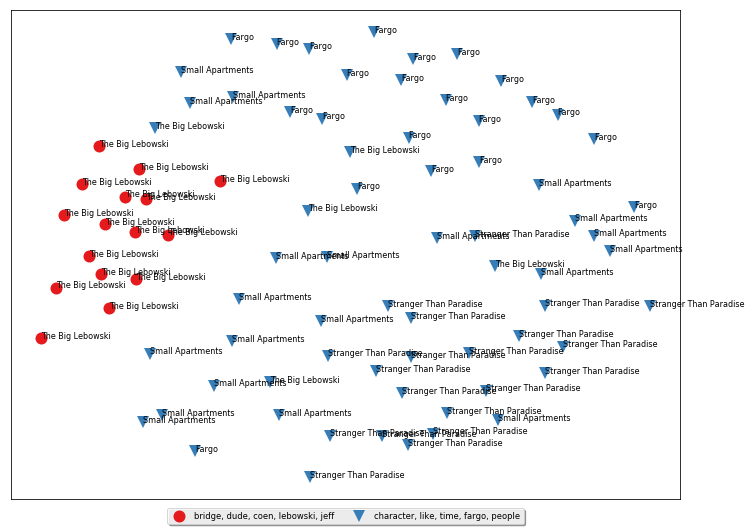

```
-=-=-=-=-=-=-=-=-=-=-=-=-=-=-=-=-=-=-=-=-=-=-=-=-=-=-=-=-=-=-=-=-=-=-=-=-=-=-=-=
Normalization Method = Retain all parts of speech
Number of Clusers = 3

-=-=-=-=-=-=-=-=-=-=-=-=-=-=-=-=-=-=-=-=-=-=-=-=-=-=-=-=-=-=-=-=-=-=-=-=-=-=-=-=
```

|  | rating_mean | rating_median | num_ratings | key_features | FAR | TBL | STP | SAP |
| --- | --- | --- | --- | --- | --- | --- | --- | --- |
| 0 | 7.83 | 9.0 | 19 | [fargo, episode, series, first, bad, tv, like, bob, great, good] | 18.0 | 1.0 | 0.0 | 0.0 |
| 1 | 6.91 | 8.0 | 47 | [character, life, think, people, end, like, time, paradise, black, plot] | 4.0 | 3.0 | 20.0 | 20.0 |
| 2 | 7.77 | 10.0 | 17 | [bridge, coen, dude, coen brother, lebowski, jeff, brother, bowling, jeff bridge, john] | 0.0 | 17.0 | 0.0 | 0.0 |

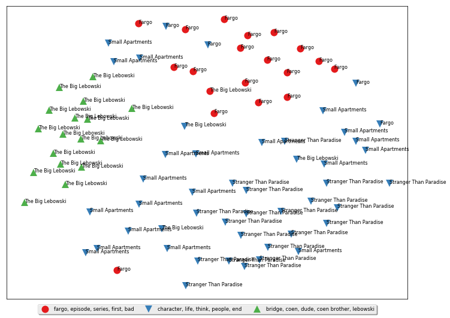

```
-=-=-=-=-=-=-=-=-=-=-=-=-=-=-=-=-=-=-=-=-=-=-=-=-=-=-=-=-=-=-=-=-=-=-=-=-=-=-=-=
Normalization Method = Retain all parts of speech
Number of Clusers = 4

-=-=-=-=-=-=-=-=-=-=-=-=-=-=-=-=-=-=-=-=-=-=-=-=-=-=-=-=-=-=-=-=-=-=-=-=-=-=-=-=
```

|  | rating_mean | rating_median | num_ratings | key_features | STP | FAR | SAP | TBL |
| --- | --- | --- | --- | --- | --- | --- | --- | --- |
| 0 | 7.44 | 8.0 | 16 | [apartment, character, little, small, performance, plot, life, way, good, actor] | 1.0 | 1.0 | 13.0 | 1.0 |
| 1 | 6.80 | 8.0 | 29 | [think, character, paradise, people, black, life, strange, jarmusch, strange paradise, much] | 19.0 | 1.0 | 7.0 | 2.0 |
| 2 | 7.19 | 9.0 | 22 | [fargo, episode, series, tv, like, really, first, bad, great, time] | 0.0 | 20.0 | 0.0 | 2.0 |
| 3 | 8.25 | 10.0 | 16 | [coen, dude, bridge, coen brother, lebowski, jeff, brother, bowling, john, jeff bridge] | 0.0 | 0.0 | 0.0 | 16.0 |

```
-=-=-=-=-=-=-=-=-=-=-=-=-=-=-=-=-=-=-=-=-=-=-=-=-=-=-=-=-=-=-=-=-=-=-=-=-=-=-=-=


+----+---------------+-----------------+---------------+-------+-------+-------+-------+
|    |   rating_mean |   rating_median |   num_ratings |   STP |   FAR |   SAP |   TBL |
|----+---------------+-----------------+---------------+-------+-------+-------+-------|
|  0 |          7.44 |               8 |            16 |     1 |     1 |    13 |     1 |
|  1 |          6.8  |               8 |            29 |    19 |     1 |     7 |     2 |
|  2 |          7.19 |               9 |            22 |     0 |    20 |     0 |     2 |
|  3 |          8.25 |              10 |            16 |     0 |     0 |     0 |    16 |
+----+---------------+-----------------+---------------+-------+-------+-------+-------+
```

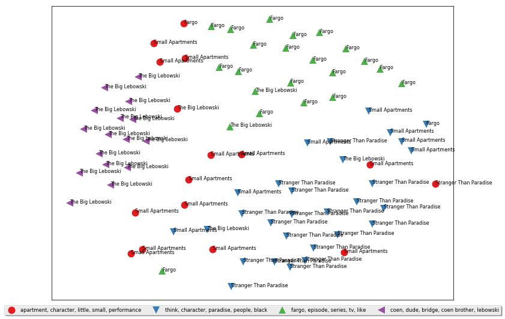

```
-=-=-=-=-=-=-=-=-=-=-=-=-=-=-=-=-=-=-=-=-=-=-=-=-=-=-=-=-=-=-=-=-=-=-=-=-=-=-=-=
Normalization Method = Retain all parts of speech
Number of Clusers = 5

-=-=-=-=-=-=-=-=-=-=-=-=-=-=-=-=-=-=-=-=-=-=-=-=-=-=-=-=-=-=-=-=-=-=-=-=-=-=-=-=
```

|  | rating_mean | rating_median | num_ratings | key_features | TBL | STP | FAR | SAP |
| --- | --- | --- | --- | --- | --- | --- | --- | --- |
| 0 | 7.58 | 9.5 | 16 | [bridge, dude, coen, lebowski, jeff, coen brother, bowling, jeff bridge, brother, buscemi] | 16.0 | 0.0 | 0.0 | 0.0 |
| 1 | 7.87 | 8.0 | 15 | [apartment, small, little, life, look, character, plot, actor, quirky, great] | 1.0 | 1.0 | 2.0 | 11.0 |
| 2 | 7.83 | 9.0 | 19 | [fargo, episode, series, first, bad, tv, like, bob, great, good] | 1.0 | 0.0 | 18.0 | 0.0 |
| 3 | 6.67 | 8.0 | 21 | [paradise, character, strange paradise, strange, time, life, jarmusch, black, seem, cleveland] | 2.0 | 17.0 | 0.0 | 2.0 |
| 4 | 6.27 | 8.0 | 12 | [think, end, anything, people, keep, love, character, much, minute, like] | 1.0 | 2.0 | 2.0 | 7.0 |

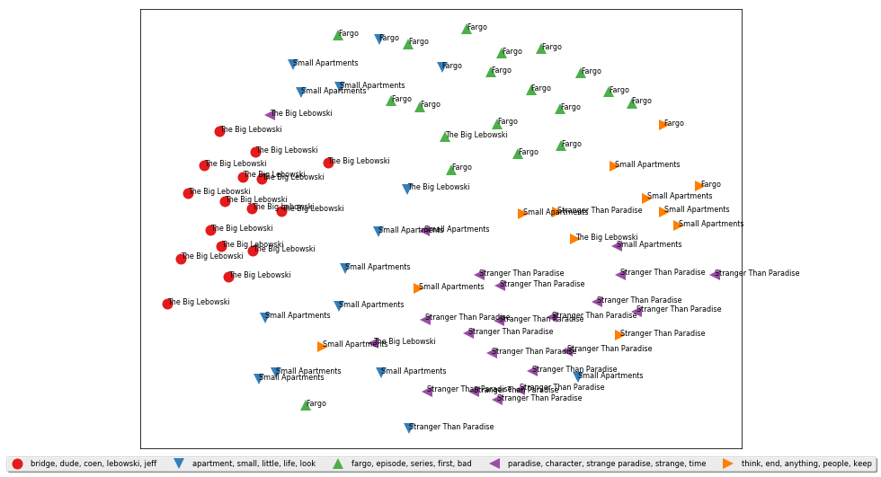

```
-=-=-=-=-=-=-=-=-=-=-=-=-=-=-=-=-=-=-=-=-=-=-=-=-=-=-=-=-=-=-=-=-=-=-=-=-=-=-=-=
Normalization Method = Retain all parts of speech
Number of Clusers = 6

-=-=-=-=-=-=-=-=-=-=-=-=-=-=-=-=-=-=-=-=-=-=-=-=-=-=-=-=-=-=-=-=-=-=-=-=-=-=-=-=
```

|  | rating_mean | rating_median | num_ratings | key_features | STP | FAR | SAP | TBL |
| --- | --- | --- | --- | --- | --- | --- | --- | --- |
| 0 | 7.33 | 9.0 | 15 | [episode, series, fargo, bad, first, tv, like, 10, break, good] | 1.0 | 13.0 | 1.0 | 0.0 |
| 1 | 8.25 | 10.0 | 16 | [coen, dude, bridge, coen brother, lebowski, jeff, brother, bowling, john, jeff bridge] | 0.0 | 0.0 | 0.0 | 16.0 |
| 2 | 7.75 | 8.0 | 14 | [paradise, strange paradise, strange, jarmusch, life, black, cleveland, character, florida, white] | 14.0 | 0.0 | 0.0 | 0.0 |
| 3 | 4.93 | 5.5 | 16 | [good, like, time, character, people, right, fargo, much, end, seem] | 2.0 | 4.0 | 5.0 | 5.0 |
| 4 | 8.42 | 8.5 | 13 | [apartment, small, well, character, life, people, great, however, quirky, think] | 2.0 | 1.0 | 10.0 | 0.0 |
| 5 | 7.44 | 10.0 | 9 | [performance, time, something, line, actor, plot, never, many, give, would] | 1.0 | 4.0 | 4.0 | 0.0 |

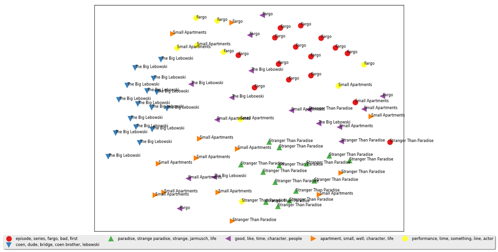

```
-=-=-=-=-=-=-=-=-=-=-=-=-=-=-=-=-=-=-=-=-=-=-=-=-=-=-=-=-=-=-=-=-=-=-=-=-=-=-=-=
Normalization Method = Retain only Noun & Verb forms
Number of Clusers = 2

-=-=-=-=-=-=-=-=-=-=-=-=-=-=-=-=-=-=-=-=-=-=-=-=-=-=-=-=-=-=-=-=-=-=-=-=-=-=-=-=
```

|  | rating_mean | rating_median | num_ratings | key_features | STP | FAR | SAP | TBL |
| --- | --- | --- | --- | --- | --- | --- | --- | --- |
| 0 | 7.27 | 8.0 | 68 | [character, think, life, time, people, end, fargo, series, episode, plot] | 20.0 | 22.0 | 20.0 | 6.0 |
| 1 | 7.36 | 9.0 | 15 | [dude, bridge, lebowski, bowling, jeff, brother, john, goodman, jeff bridge, steve] | 0.0 | 0.0 | 0.0 | 15.0 |

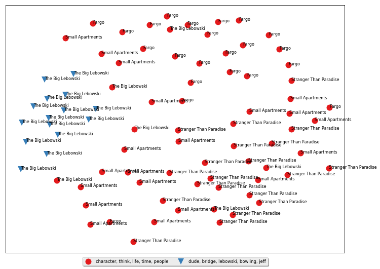

```
-=-=-=-=-=-=-=-=-=-=-=-=-=-=-=-=-=-=-=-=-=-=-=-=-=-=-=-=-=-=-=-=-=-=-=-=-=-=-=-=
Normalization Method = Retain only Noun & Verb forms
Number of Clusers = 3

-=-=-=-=-=-=-=-=-=-=-=-=-=-=-=-=-=-=-=-=-=-=-=-=-=-=-=-=-=-=-=-=-=-=-=-=-=-=-=-=
```

|  | rating_mean | rating_median | num_ratings | key_features | STP | FAR | SAP | TBL |
| --- | --- | --- | --- | --- | --- | --- | --- | --- |
| 0 | 7.30 | 9.0 | 31 | [fargo, episode, series, plot, tv, actor, end, character, performance, line] | 2.0 | 20.0 | 8.0 | 1.0 |
| 1 | 6.97 | 8.0 | 33 | [character, life, people, paradise, think, seem, time, take, meaning, florida] | 17.0 | 2.0 | 11.0 | 3.0 |
| 2 | 7.87 | 9.0 | 19 | [brother, dude, bridge, lebowski, john, bowling, goodman, jeff, jeff bridge, play] | 1.0 | 0.0 | 1.0 | 17.0 |

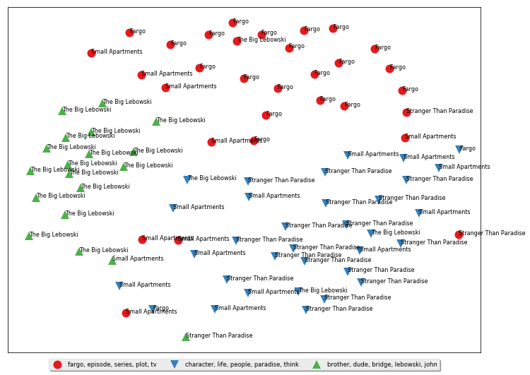

```
-=-=-=-=-=-=-=-=-=-=-=-=-=-=-=-=-=-=-=-=-=-=-=-=-=-=-=-=-=-=-=-=-=-=-=-=-=-=-=-=
Normalization Method = Retain only Noun & Verb forms
Number of Clusers = 4

-=-=-=-=-=-=-=-=-=-=-=-=-=-=-=-=-=-=-=-=-=-=-=-=-=-=-=-=-=-=-=-=-=-=-=-=-=-=-=-=
```

|  | rating_mean | rating_median | num_ratings | key_features | STP | FAR | SAP | TBL |
| --- | --- | --- | --- | --- | --- | --- | --- | --- |
| 0 | 5.63 | 8.0 | 19 | [think, end, people, give, plot, anything, star, time, meaning, line] | 8.0 | 2.0 | 8.0 | 1.0 |
| 1 | 7.79 | 9.0 | 20 | [fargo, episode, series, tv, something, time, character, cast, end, people] | 0.0 | 19.0 | 0.0 | 1.0 |
| 2 | 7.54 | 8.0 | 25 | [character, life, paradise, apartment, moment, people, seem, time, take, florida] | 12.0 | 0.0 | 11.0 | 2.0 |
| 3 | 8.00 | 10.0 | 19 | [dude, bridge, brother, lebowski, john, bowling, goodman, jeff, character, humor] | 0.0 | 1.0 | 1.0 | 17.0 |

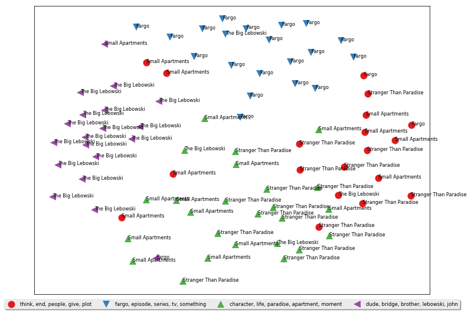

```
-=-=-=-=-=-=-=-=-=-=-=-=-=-=-=-=-=-=-=-=-=-=-=-=-=-=-=-=-=-=-=-=-=-=-=-=-=-=-=-=
Normalization Method = Retain only Noun & Verb forms
Number of Clusers = 5

-=-=-=-=-=-=-=-=-=-=-=-=-=-=-=-=-=-=-=-=-=-=-=-=-=-=-=-=-=-=-=-=-=-=-=-=-=-=-=-=
```

|  | rating_mean | rating_median | num_ratings | key_features | STP | FAR | SAP | TBL |
| --- | --- | --- | --- | --- | --- | --- | --- | --- |
| 0 | 6.55 | 9.0 | 11 | [series, episode, tv, line, plot, end, cast, time, start, acting] | 1.0 | 10.0 | 0.0 | 0.0 |
| 1 | 6.89 | 8.0 | 32 | [character, life, paradise, people, think, seem, time, take, florida, end] | 18.0 | 4.0 | 7.0 | 3.0 |
| 2 | 8.25 | 10.0 | 16 | [dude, brother, bridge, lebowski, john, bowling, goodman, jeff, steve, john goodman] | 0.0 | 0.0 | 0.0 | 16.0 |
| 3 | 7.17 | 9.0 | 7 | [fargo, episode, character, people, turn, experience, tv, nothing, set, actor] | 0.0 | 6.0 | 0.0 | 1.0 |
| 4 | 7.76 | 8.0 | 17 | [apartment, actor, plot, performance, character, comedy, surprise, guy, way, look] | 1.0 | 2.0 | 13.0 | 1.0 |

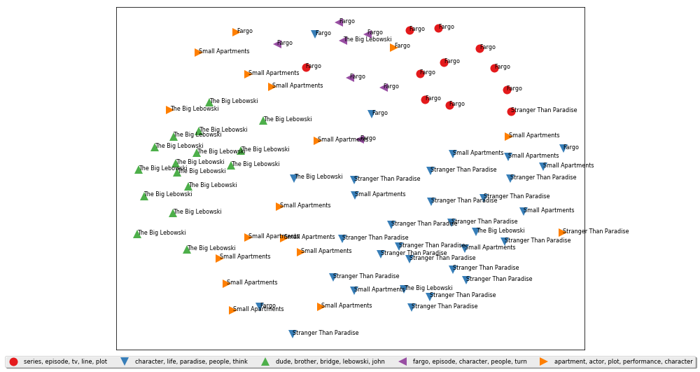

```
-=-=-=-=-=-=-=-=-=-=-=-=-=-=-=-=-=-=-=-=-=-=-=-=-=-=-=-=-=-=-=-=-=-=-=-=-=-=-=-=
Normalization Method = Retain only Noun & Verb forms
Number of Clusers = 6

-=-=-=-=-=-=-=-=-=-=-=-=-=-=-=-=-=-=-=-=-=-=-=-=-=-=-=-=-=-=-=-=-=-=-=-=-=-=-=-=
```

|  | rating_mean | rating_median | num_ratings | key_features | STP | FAR | SAP | TBL |
| --- | --- | --- | --- | --- | --- | --- | --- | --- |
| 0 | 7.18 | 8.0 | 12 | [think, meaning, anything, give, life, love, people, keep, way, need] | 1.0 | 1.0 | 8.0 | 2.0 |
| 1 | 6.88 | 8.0 | 8 | [series, episode, tv, cast, line, character, enjoy, anything, fargo, life] | 1.0 | 7.0 | 0.0 | 0.0 |
| 2 | 7.77 | 10.0 | 17 | [dude, bridge, brother, lebowski, john, bowling, goodman, jeff, jeff bridge, character] | 0.0 | 0.0 | 0.0 | 17.0 |
| 3 | 7.50 | 8.0 | 19 | [character, paradise, life, people, florida, take, cleveland, time, seem, day] | 14.0 | 1.0 | 3.0 | 1.0 |
| 4 | 6.18 | 7.0 | 11 | [plot, apartment, character, guy, end, look, comedy, actor, happen, acting] | 2.0 | 1.0 | 8.0 | 0.0 |
| 5 | 7.73 | 9.0 | 16 | [fargo, episode, something, tv, character, play, turn, time, masterpiece, performance] | 2.0 | 12.0 | 1.0 | 1.0 |

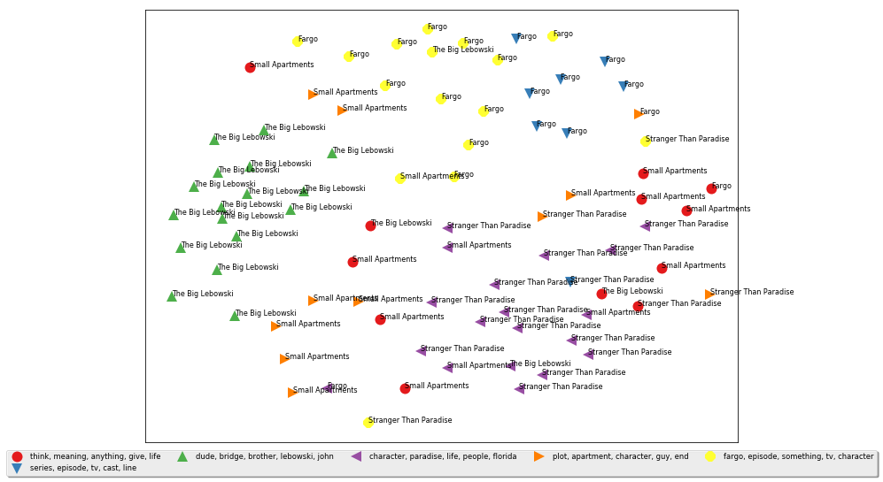

```python
# ... -=-=-=-=-=-=-=-=-=-=-=-=-=-=-=-=-=-=-=-=-=-=-=-=-=-=-=-=-=-=-=-=-
# ... cluster evaluation
# ... - 2 loops
# ...   - normalization method (retain all POS or retain only Noun and Verb forms)
# ...   - number of clusters from 2 to 6
# ... -=-=-=-=-=-=-=-=-=-=-=-=-=-=-=-=-=-=-=-=-=-=-=-=-=-=-=-=-=-=-=-=-

norm = ['Retain all parts of speech', 'Retain only Noun & Verb forms']

for normalization in range(2) :

# ...  choose normalization method

    if(normalization == 0) :
        norm_reviews = normalize_corpus(corpus)   # all POS
    else :
        norm_reviews = normalize_corpus_NV(corpus)  # only Noun & Verb tokens retained

    tfidf_vectorizer, tfidf_feature_matrix = build_feature_matrix(norm_reviews,
                                                            feature_type = 'tfidf',
                                                            ngram_range = (1, 2),
                                                            min_df = 0.1,
                                                            max_df = 0.9)

    feature_names = tfidf_vectorizer.get_feature_names()

# ... vary cluster size from 2 to 6

    for num_clusters in range(2,7) :

        df_cluster = df_imdb_subset

        print '-='*40
        print 'Normalization Method = %s' % (norm[normalization])
        print 'Number of Clusers = %d\n' % (num_clusters)
        print '-='*40

        km_obj, clusters = k_means(feature_matrix = tfidf_feature_matrix, num_clusters = num_clusters)

        df_cluster['cluster'] = clusters

        cluster_data =  get_cluster_data(clustering_obj = km_obj,
                                         df_to_cluster = df_cluster,
                                         feature_names = feature_names,
                                         num_clusters = num_clusters,
                                         topn_features = 20)

#        print_cluster_data(cluster_data)

        df_clstr =  make_cluster_agg(clustering_obj = km_obj,
                                            df_to_cluster = df_cluster,
                                            feature_names = feature_names,
                                            num_clusters = num_clusters,
                                            topn_features = 10,
                                            movie_list = movie_list,
                                            movie_list_abbr = movie_list_abbr)
        df_clstr
        print '-='*40
        print '\n'

# ... save some subsets for results summary

        if (num_clusters == 4) :
            if(normalization == 0):
                df_clstr_sub1 = df_clstr.copy()
                del df_clstr_sub1['key_features']
#                print tabulate(df_clstr_sub1, headers='keys', tablefmt='psql')
                df_clstr_sub2 = df_clstr['key_features'].copy()
            if(normalization == 1):
                df_clstr_sub3 = df_clstr.copy()
                del df_clstr_sub3['key_features']
                df_clstr_sub4 = df_clstr['key_features'].copy()

        plot_clusters(num_clusters = num_clusters,
                      feature_matrix = tfidf_feature_matrix,
                      cluster_data = cluster_data,
                      movie_data = df_cluster,
                      plot_size = (12, 9))
```